# Session 3: Data analysis and visualization

Aim: To provide tools for extracting answers from your data.

**Intended Learning Outcomes:**

At the end of the session a successful student will be able to:

- Build an analysis dataset
- Filter, group, and summarise data to answer questions
- Build presentation-ready tables using R
- Understand the key concepts behind making graphs with ggplot

## What will be covered today?

- Looking at your data
- Building an analysis dataset
- Answering questions with data
- Visualising data using ggplot
- Useful resources
- Additional questions and workflows

## Looking at your data

Section from Epidemiologist R handbook- [17 Descriptive Tables](https://epirhandbook.com/descriptive-tables.html)

There are many functions available to look at descriptive statistics from your dataset. For this example, we will use a function that is included in the basic installation of R.

```r
library(here)
pacman::p_load(here)
africa_covid_cases_long <- read.csv(here('data', 'africa_covid_cases_long.csv'))
summary(africa_covid_cases_long)
```

```
##        X             ISO            COUNTRY_NAME       AFRICAN_REGION
##  Min.   :    1   Length:25917       Length:25917       Length:25917
##  1st Qu.: 6480   Class :character   Class :character   Class :character
##  Median :12959   Mode  :character   Mode  :character   Mode  :character
##  Mean   :12959
##  3rd Qu.:19438
##  Max.   :25917
##
##    excel_date        cases         date_format
##  Min.   :43831   Min.   : -209.0   Length:25917
##  1st Qu.:43953   1st Qu.:    0.0   Class :character
##  Median :44075   Median :    7.0   Mode  :character
##  Mean   :44075   Mean   :  177.6
##  3rd Qu.:44197   3rd Qu.:   78.0
##  Max.   :44319   Max.   :21980.0
##                  NA's   :231
```

## Building an analysis dataset

Before analysing the data, it is good to generate a new dataset that only contains the variables you need to analyse.

So what variables do we have in *`africa_covid_cases_long`*

```r
names(africa_covid_cases_long)
```

```
## [1] "X"              "ISO"            "COUNTRY_NAME"   "AFRICAN_REGION"
## [5] "excel_date"     "cases"          "date_format"
```

We can select the variables we want to keep using the select function from the dplyr package. `dplyr` is a core package of the `tidyverse` so it is loaded when you write `library(tidyverse).`

```r
library(tidyverse) # this will load the dplyr package along with other core tidyverse packages
library(dplyr) # this will only load the dplyr package
# you don't need to run both lines! Loading a package twice will not have any negative consequences. But it makes your code less efficient to read!
analysis_dataset <- africa_covid_cases_long %>% #use this dataset
  select(date_format,AFRICAN_REGION, COUNTRY_NAME, cases) #select the named columns
```

The `select` function from the `dplyr` package is very useful. It is used to tell R which columns you want to keep in the new data frame. We can look at the first few rows of the dataset we have created to check that we have selected the correct variables.

```r
head(analysis_dataset)
```

```
##   date_format  AFRICAN_REGION COUNTRY_NAME cases
## 1  2020-01-01 Northern Africa      Algeria     0
## 2  2020-01-02 Northern Africa      Algeria     0
## 3  2020-01-03 Northern Africa      Algeria     0
## 4  2020-01-04 Northern Africa      Algeria     0
## 5  2020-01-05 Northern Africa      Algeria     0
## 6  2020-01-06 Northern Africa      Algeria     0
```

The select function can also be used to rename selected variables.

```r
analysis_dataset <- africa_covid_cases_long %>%
  select(date_format,region=AFRICAN_REGION, country=COUNTRY_NAME, cases) %>%
  mutate(date=lubridate::ymd(date_format))
```

We have renamed `AFRICAN_REGION` and `COUNTRY_NAME` as `region` and `country`.

```r
head(analysis_dataset)
```

```
##   date_format          region country cases       date
## 1  2020-01-01 Northern Africa Algeria     0 2020-01-01
## 2  2020-01-02 Northern Africa Algeria     0 2020-01-02
## 3  2020-01-03 Northern Africa Algeria     0 2020-01-03
## 4  2020-01-04 Northern Africa Algeria     0 2020-01-04
## 5  2020-01-05 Northern Africa Algeria     0 2020-01-05
## 6  2020-01-06 Northern Africa Algeria     0 2020-01-06
```

## Answering questions with data

The Epidemiologist R handbook has several comprehensive sections focusing on data analysis. We will continue to work with the dataset we have built while applying some of the examples from the handbook.

So far, we have:

- Imported the data from an Excel worksheet
- Reshaped the data into a “tidy” format
- Changed the format of a variable to a date
- Selected only the variables we want to use for the analysis

Now we can start to use the dataset to answer questions. The `dplyr` package contains many useful functions for analysing data. Some of these functions are covered in the Epidemiologist R Handbook - [Section 17.4](https://epirhandbook.com/descriptive-tables.html#dplyr-package). We will use some of these functions to answer questions using our dataset.

*How many confirmed cases of COVID-19 have been recorded in Africa?*

```r
analysis_dataset %>%  # Tell R what dataset we want to use
    summarise(total_covid_cases=sum(cases))  #Tell R you want to sum all cases
```

```
##   total_covid_cases
## 1                NA
```

The answer is “NA”, which stands for “Not Available”. This is a good example of how R “sees” missing data

- There may be dates in our dataset where there were no confirmed cases of COVID-19 recorded.
- When data are missing, R will display “NA” for the variable.
- If you try to run a calculation on data where there is one or more “NA” values, the results will be “NA”.

One option for dealing with missing values in R is to exclude “NA” values from calculations. To do this we, can add an additional argument to the function to remove any record with “NA” in the variable “cases”.

```r
total_covid_cases <- analysis_dataset %>%
    summarise(total_covid_cases=sum(cases, na.rm=TRUE)) #Tell R you want to sum all cases but remove NA values - values with "missing" data
total_covid_cases
```

```
##   total_covid_cases
## 1           4561465
```

This command has now excluded NA values and has provided us with an answer for the number of confirmed COVID-19 cases in Africa - 4561465.

### Grouping and pivoting data

`group_by` is a very powerful function for summarising data. You can instruct R to recognise specific groups in your data. Functions can then be applied to these groups providing you with additional information.

*How many confirmed cases of COVID-19 have been recorded in Africa, by region?*

```r
total_covid_cases_region <- analysis_dataset %>%
  group_by(region) %>% #use the values in the region column to group the data
    summarise(total_covid_cases=sum(cases, na.rm=TRUE)) #for each region, sum the number of cases
total_covid_cases_region
```

```
## # A tibble: 5 x 2
##   region          total_covid_cases
##   <chr>                       <int>
## 1 Central Africa             161353
## 2 Eastern Africa             622537
## 3 Northern Africa           1371469
## 4 Southern Africa           1970137
## 5 Western Africa             435969
```

The `arrange` function can be used to sort the results. In this case, we have instructed R to sort the results by the `total_covid_cases` variable, from highest to lowest value.

```r
total_covid_cases_region_sort <- analysis_dataset %>%
  group_by(region) %>% #use the values in the region column to group the data
    summarise(total_covid_cases=sum(cases, na.rm=TRUE)) %>%
  arrange(-total_covid_cases)
total_covid_cases_region_sort
```

```
## # A tibble: 5 x 2
##   region          total_covid_cases
##   <chr>                       <int>
## 1 Southern Africa           1970137
## 2 Northern Africa           1371469
## 3 Eastern Africa             622537
## 4 Western Africa             435969
## 5 Central Africa             161353
```

We can add multiple variables to `group_by`.

If we add region and country to the group_by command, sort from highest to lowest, we can see which countries reported the most confirmed COVID-19 cases.

```r
total_covid_cases_region_country_sort <- analysis_dataset %>%
  group_by(region, country) %>%
    summarise(total_covid_cases=sum(cases, na.rm=TRUE)) %>% #for each region, sum the number of cases
  arrange(-total_covid_cases) #sort the result from highest to lowest number of cases
total_covid_cases_region_country_sort
```

```
## # A tibble: 53 x 3
## # Groups:   region [5]
##    region          country      total_covid_cases
##    <chr>           <chr>                    <int>
##  1 Southern Africa South Africa           1584064
##  2 Northern Africa Morocco                 511856
##  3 Northern Africa Tunisia                 311743
##  4 Eastern Africa  Ethiopia                258353
##  5 Northern Africa Egypt                   228584
##  6 Northern Africa Libya                   178335
##  7 Western Africa  Nigeria                 165199
##  8 Eastern Africa  Kenya                   160559
##  9 Northern Africa Algeria                 122522
## 10 Western Africa  Ghana                    92683
## # … with 43 more rows
```

### Filtering data

Another useful function is `filter` which can be used to apply filters to calculations.

We can repeat the previous calculation, but then add a filter to only include results from countries in Northern Africa.

```r
analysis_dataset %>%
  group_by(region, country) %>%
    summarise(total_covid_cases=sum(cases, na.rm=TRUE)) %>%
  arrange(-total_covid_cases) %>% #sort the result from highest to lowest number of cases
  filter(region=="Northern Africa") #filter the result to only include rows where the region is "Northern Africa"
```

```
## # A tibble: 6 x 3
## # Groups:   region [1]
##   region          country    total_covid_cases
##   <chr>           <chr>                  <int>
## 1 Northern Africa Morocco               511856
## 2 Northern Africa Tunisia               311743
## 3 Northern Africa Egypt                 228584
## 4 Northern Africa Libya                 178335
## 5 Northern Africa Algeria               122522
## 6 Northern Africa Mauritania             18429
```

The filter can be applied at any point within the calculation. For very complex calculations, it is helpful to apply the filter as early as possible. This reduces the number of records before the complex portion of the calculation occurs.

`filter` can also be used to make data frames

```r
northern_africa <- analysis_dataset %>%
  filter(region=="Northern Africa")
head(northern_africa)
```

```
##   date_format          region country cases       date
## 1  2020-01-01 Northern Africa Algeria     0 2020-01-01
## 2  2020-01-02 Northern Africa Algeria     0 2020-01-02
## 3  2020-01-03 Northern Africa Algeria     0 2020-01-03
## 4  2020-01-04 Northern Africa Algeria     0 2020-01-04
## 5  2020-01-05 Northern Africa Algeria     0 2020-01-05
## 6  2020-01-06 Northern Africa Algeria     0 2020-01-06
```

Using filters, we can answer additional questions.

What percentage of North Africa’s confirmed COVID-19 cases were recorded in each country in North Africa?

```r
#to convert the calculation to percentage we will need to install and load an additional package called "scales"
pacman::p_load(scales)

northern_africa_cases_country <- northern_africa %>%
  group_by(country) %>%
  summarise(total_covid_cases=sum(cases, na.rm=TRUE)) %>%
  mutate(percentage=scales::percent(total_covid_cases/sum(total_covid_cases))) %>%
  #with this mutate command we are telling r to divide the total number of covid cases for each country by the total number of covid cases for all countries in northern africa
  arrange(-total_covid_cases)
northern_africa_cases_country
```

```
## # A tibble: 6 x 3
##   country    total_covid_cases percentage
##   <chr>                  <int> <chr>
## 1 Morocco               511856 37.3%
## 2 Tunisia               311743 22.7%
## 3 Egypt                 228584 16.7%
## 4 Libya                 178335 13.0%
## 5 Algeria               122522 8.9%
## 6 Mauritania             18429 1.3%
```

## Visualising data using ggplot

One of the major strengths of R is visualising data. There are many packages which have functions you can use to make graphs, tables, maps…the list is endless! The first package of functions we will use for visualising data is another core `tidyverse` package called `ggplot2.` This is commonly referred to as `ggplot`.

We have already loaded the package when we ran `library(tidyverse)`. You can also choose to only load the ggplot2 package by typing `library(ggplot2)`.

```r
library(ggplot2)
```

The Epidemiologist R handbook has 2 sections focused on `ggplot`:

1. [ggplot basics](https://epirhandbook.com/ggplot-basics.html)
2. [ggplot tips](https://epirhandbook.com/ggplot-tips.html)

These sections contain very helpful explanations of many of the functions available with ggplot. There are also a number of excellent references for every type of graph you want to make. We will walk through some common examples to teach some of the most common approaches.

### Epicurves

Firstly, we will produce epicurves to describe the distribution of COVID-19 cases (y axis) over time (x axis). Make a graph of confirmed COVID-19 cases in Northern Africa. The Epidemiologist R handbook has a very useful section on this topic - 32.3 [Epicurves with ggplot](https://epirhandbook.com/epidemic-curves.html#epicurves-with-ggplot2)

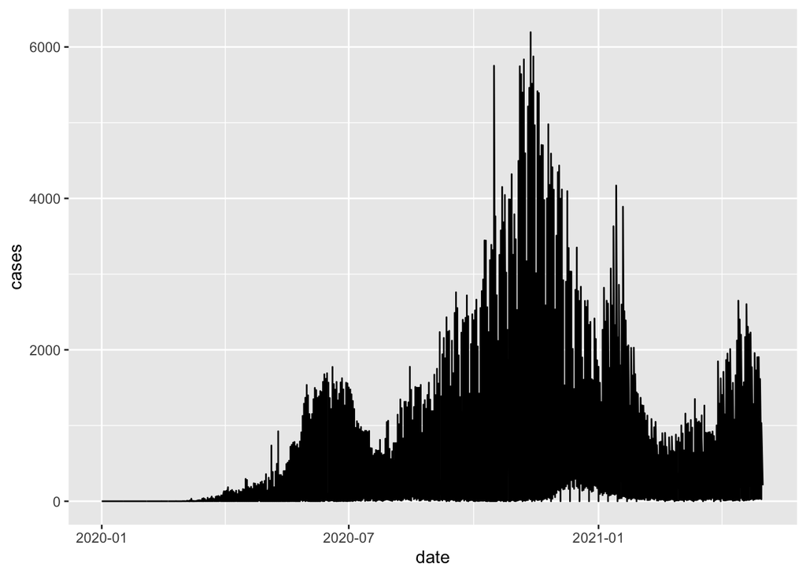

```r
ggplot(northern_africa, aes(x=date,y=cases)) +
  geom_line()
```

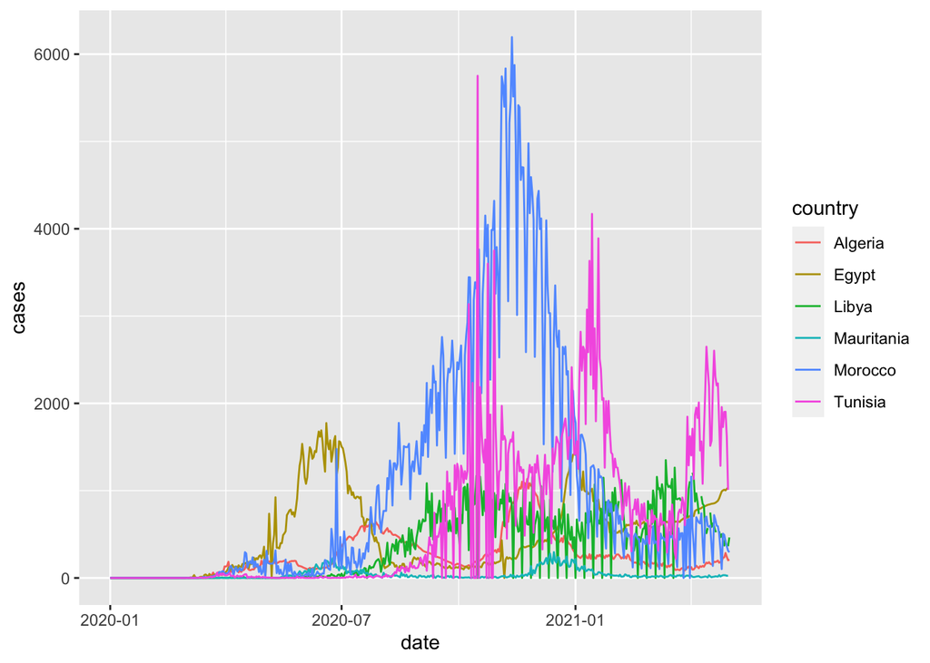

```r
ggplot(northern_africa, aes(x=date,y=cases, color=country)) +
  geom_line()
```

To make the graph more presentable, we can add more options to the ggplot command.

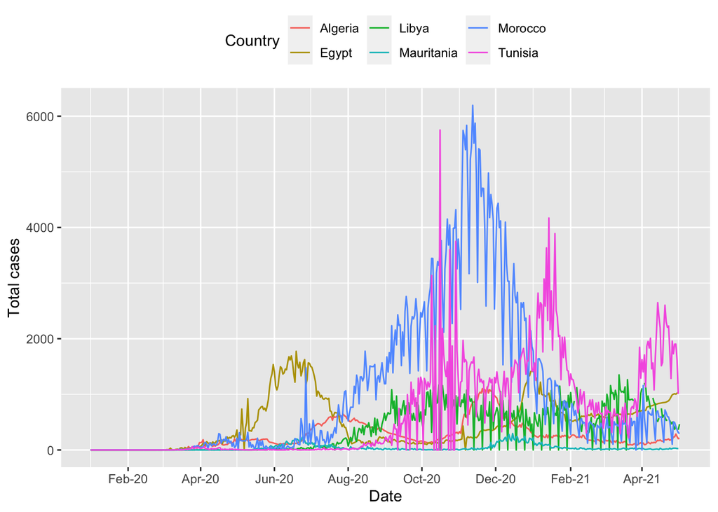

```r
ggplot(northern_africa, aes(x=date,y=cases, color=country)) +
  geom_line() +
  labs(x='Date', y='Total cases', color='Country') + #label axes
  theme(legend.position='top') + #place legend at top of graph
  scale_x_date(date_breaks = '2 months', #set x axis to have 2 month breaks
               date_minor_breaks = '1 month', #set x axis to have 1 month breaks
               date_labels = '%b-%y') #change label for x axis
```

More information on plotting time-series data using ggplot can be found [here](https://www.r-graph-gallery.com/279-plotting-time-series-with-ggplot2.html).

It is still difficult to see the data for each country. There is a helpful command called `facet_wrap` to fix this and show multiple epicurves by country.

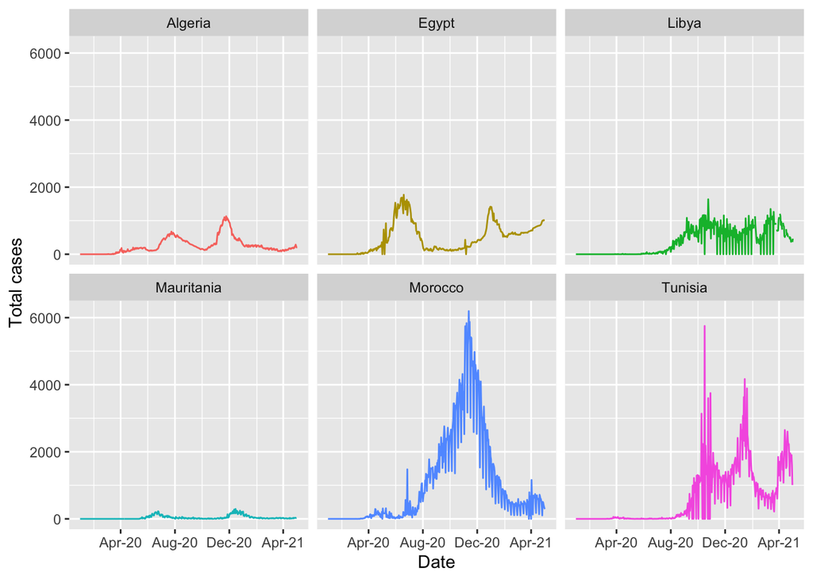

```r
ggplot(northern_africa, aes(x=date,y=cases, color=country)) +
  geom_line() +
  labs(x='Date', y='Total cases') + #label axes
  theme(legend.position='none') + #remove legend by setting position to 'none'
  scale_x_date(date_breaks = '4 months', #set x axis to have 2 month breaks
               date_minor_breaks = '2 months', #set x axis to have 1 month breaks
               date_labels = '%b-%y') + #change label for x axis
  facet_wrap(~country) # this will create a separate graph for each country
```

#### Highlighting

When data are presented for multiple countries, it can be helpful to highlight specific countries to show their path. This can be easily done in ggplot using the package gghighlight and is covered in the Epidemiologist R handbook Section [31.8 Highlighting](https://epirhandbook.com/ggplot-tips.html#highlighting).

```r
pacman::p_load(gghighlight)
highlight_country_morocco_gph <- ggplot(northern_africa, aes(x=date,y=cases, color=country)) +
  geom_line() +
  gghighlight::gghighlight(country == "Morocco") + #highlight data reported by Morocco
  labs(x='Date', y='Total cases') + #label axes
  theme(legend.position='none') + #remove legend by setting position to 'none'
  scale_x_date(date_breaks = '4 months', #set x axis to have 2 month breaks
               date_minor_breaks = '2 months', #set x axis to have 1 month breaks
               date_labels = '%b-%y')  #change label for x axis
```

```
## label_key: country
```

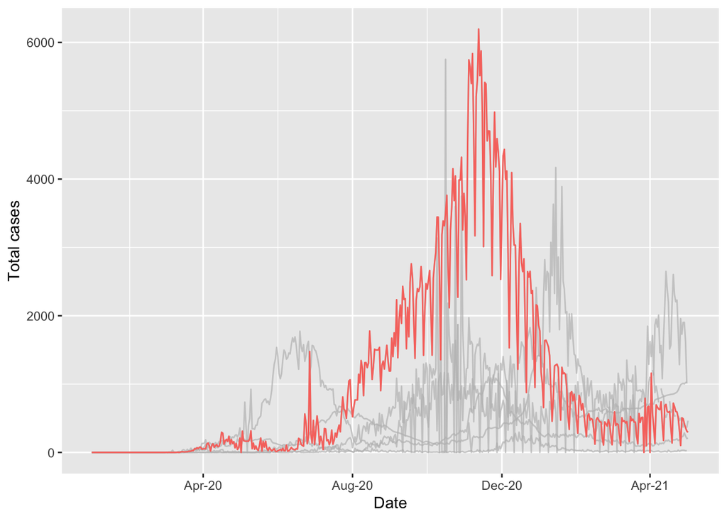

```r
 highlight_country_morocco_gph
```

Highlighting can also be applied to graphs with the facet_wrap function applied.

```r
highlight_country_facet_gph <- ggplot(northern_africa, aes(x=date,y=cases, color=country)) +
  geom_line() +
  labs(x='Date', y='Total cases') + #label axes
  gghighlight::gghighlight() + #highlight each country independently
  theme(legend.position='none') + #remove legend by setting position to 'none'
  scale_x_date(date_breaks = '4 months', #set x axis to have 2 month breaks
               date_minor_breaks = '2 months', #set x axis to have 1 month breaks
               date_labels = '%b-%y') + #change label for x axis
  facet_wrap(~country) # this will create a separate graph for each country
```

```
## label_key: country
```

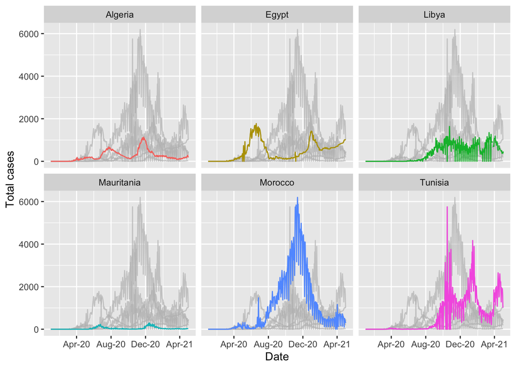

```r
highlight_country_facet_gph
```

### Building your confidence

This code can seem overwhelming at first. The method to build a ggplot is very different to the ‘point and click’ method used in Excel. It will be very helpful to your learning to work through each step and see what changes when you delete/add code. A very helpful package called [eqsuisse](https://github.com/dreamRs/esquisse) can help you understand more about how ggplot works.

```r
pacman::p_load(esquisse)
esquisse::esquisser()
```

Using this package, you can drag and drop variables, change the type of graph and make a lot customisations. You can also click the button “code” and it will show you what the ggplot code is for each graph you have selected. This code can then be copied into your R script.

## Useful resources

Epidemiologist R handbook

- Data Management
  - 15: [De-duplication](https://epirhandbook.com/de-duplication.html)
- Analysis
  - 17: [Descriptive tables](https://epirhandbook.com/descriptive-tables.html)
  - 22: [Moving averages](https://epirhandbook.com/moving-averages.html)
- Data visualization
  - 30: [ggplot basics](https://epirhandbook.com/ggplot-basics.html)
  - 31: [ggplot tips](https://epirhandbook.com/ggplot-tips.html)
  - 32: [Epidemic curves](https://epirhandbook.com/epidemic-curves.html)
- Reports and dashboards
  - 40: [Reports with R Markdown](https://epirhandbook.com/reports-with-r-markdown.html)

[Reproducible research in R](https://monashdatafluency.github.io/r-rep-res/)

[Data Visualization: A practical introduction](https://socviz.co/)

[Lessons from Edward Tufte](https://anilbas.github.io/teaching/hci/week13/Tufte.pdf)

## Additional questions and workflows

### *When was the first confirmed case of COVID-19 in Northern Africa?*

```r
first_cases_northern_africa <- northern_africa %>% # use the northern_africa data
  filter(cases>0) %>% #filter to only include rows with a case value of greater than 0
  filter(date == min(date, na.rm=TRUE))  #keep the row with the minimum (first) date
first_cases_northern_africa
```

```
##   date_format          region country cases       date
## 1  2020-02-14 Northern Africa   Egypt     1 2020-02-14
```

Here we have added 2 filters:

1. Only keep records where the value for `cases` is higher than 0.
2. Only keep records where the value for `date` is equal to the minimum value for `date.` We have also added the `na.rm=TRUE` command from a previous step. If you don’t know the data very well, it is good practice to add this command.

When was the first confirmed case of COVID-19 in Northern Africa, by country?

```r
first_case_northern_africa_country <- northern_africa %>%
  group_by(country) %>%
  filter(cases>0) %>%
  filter(date == min(date, na.rm=TRUE))
first_case_northern_africa_country
```

```
## # A tibble: 6 x 5
## # Groups:   country [6]
##   date_format region          country    cases date
##   <chr>       <chr>           <chr>      <int> <date>
## 1 2020-02-25  Northern Africa Algeria        1 2020-02-25
## 2 2020-02-14  Northern Africa Egypt          1 2020-02-14
## 3 2020-03-24  Northern Africa Libya          1 2020-03-24
## 4 2020-03-13  Northern Africa Mauritania     1 2020-03-13
## 5 2020-03-02  Northern Africa Morocco        1 2020-03-02
## 6 2020-03-02  Northern Africa Tunisia        1 2020-03-02
```

The filter function can also be used to exclude certain records from the analysis

```r
first_case_northern_africa_country_exclude_tunisia <- northern_africa %>%
  group_by(country) %>%
  filter(cases>0) %>%
  filter(date == min(date, na.rm=TRUE)) %>%
  #filter(!country=="Tunisia") %>%
  filter(country!="Tunisia") #both methods for excluding results (in this case excluding results where the value for country is Tunisia) can be used
first_case_northern_africa_country_exclude_tunisia
```

```
## # A tibble: 5 x 5
## # Groups:   country [5]
##   date_format region          country    cases date
##   <chr>       <chr>           <chr>      <int> <date>
## 1 2020-02-25  Northern Africa Algeria        1 2020-02-25
## 2 2020-02-14  Northern Africa Egypt          1 2020-02-14
## 3 2020-03-24  Northern Africa Libya          1 2020-03-24
## 4 2020-03-13  Northern Africa Mauritania     1 2020-03-13
## 5 2020-03-02  Northern Africa Morocco        1 2020-03-02
```

On what date was the 100th case of COVID-19 reported from each country in Northern Africa?

```r
first_cases_northern_africa_data <- northern_africa %>%
  group_by(country) %>%
  mutate(cumulative_cases=cumsum(cases)) %>%
  filter(cumulative_cases>=100) %>%
  slice(1) %>%
  pull(date, country)
```

Here we have introduced two new functions, `slice` and `pull`. `slice` can be used to select specific rows from a dataset. In this case, we have added a column which is the cumulative number of cases, selected the first row after filtering the dataset to only include results where the value is greater than or equal to 100, and then selected the first row using the slice command. An additional function is the `pull` command. This is useful when you want to extract specific values from the result.

```r
first_100cases <- northern_africa %>%
  group_by(country) %>%
  mutate(cumulative_cases=cumsum(cases)) %>%
  filter(cumulative_cases>=100) %>%
  slice(1) %>%
  pull(date, country)
```

The Epidemiologist R Handbook has a thorough section on slicing data: 15.3- [Slicing](https://epirhandbook.com/de-duplication.html?q=slice#slicing)

### Using the results in RMarkdown

RStudio has a powerful tool for writing documents called RMarkdown. These slides were written in RMarkdown and there are many resources online built using the same approach.

One major benefit of RMarkdown is that it is an excellent tool for reproducible research.

[figure not shown]

RMarkdown will not be covered during this training, but there are excellent resources online providing walk-through guides and some are included in the useful resources section of this session.

Here is one example:

If we write this text

```r
The first COVID-19 case recorded in Northern Africa was in `r first_cases_northern_africa %>% pull(country)` on `r first_cases_northern_africa %>% pull(date)`.
```

it will work through the functions and this is the result

The first COVID-19 case recorded in Northern Africa was in Egypt on 2020-02-14.

If you were to re-run the report with data from eastern Africa, the figures would update using the same functions on the new dataset for eastern Africa. This is very helpful when multiple people work on a report that needs to be run at regular intervals.

### Moving averages

The dataset is currently set up so that each row contains information on the number of recorded COVID-19 cases for a specific date for a specified country. One calculation that we may be interested in is the overall trend of case numbers over time. For this, we can calculate cumulative values and averages to identify any trends in the data.

To demonstrate this, we will filter the dataset only to include one country - in this case, Morocco.

```r
morocco_covid_cases <- northern_africa %>%
  filter(country=="Morocco")
```

When data are collected daily, it can be helpful to apply functions to improve the interpretation of trends that may be present in the data. For example, with this COVID dataset, data are available for 489 days between January 1, 2020, & May 3, 2021. There will be some days when 0 cases are reported, and there will be some days when many more cases are reported. Some of these differences may be due to delays in reporting cases if, for example, reporting does not take place at the weekend.

There are many functions in the `slider` package that can help us partially account for reporting delays. These examples use code from the Epidemiologist R handbook: 22.2 [Calculate with slider](https://epirhandbook.com/moving-averages.html#calculate-with-slider).

#### Rolling seven-day average (mean) of cases

```r
pacman::p_load(slider)

morocco_covid_cases_mean <- morocco_covid_cases %>%
  mutate(                                # create new columns
    # Using slide_dbl()
    ###################
    reg_7day = slide_dbl(
      cases,                         # calculate on new_cases
      .f = ~mean(.x, na.rm = T),          # function is sum() with missing values removed
      .before = 7))                     # window is the ROW and 6 prior ROWS
```

We have now created a new variable which calculates the 7-day moving average of cases. In the visualisation session of this training, we will compare the graphs of cases to the seven-day moving average to show the difference between the two indicators.

```r
morocco_covid_cases_mean <- morocco_covid_cases %>%
    mutate(                                # create new columns
    # Using slide_dbl()
    ###################
    cases_7day_mean = slide_dbl(
      cases,                         # calculate on new_cases
      .f = ~mean(.x, na.rm = T),          # function is sum() with missing values removed
      .before = 7),                  # window is the ROW and 6 prior ROWS
     cases_14day_mean = slide_dbl(
      cases,                         # calculate on new_cases
      .f = ~mean(.x, na.rm = T),          # function is sum() with missing values removed
      .before = 14))                  # window is the ROW and 6 prior ROWS
```

### Picking the right graph

With so many options to choose from you will find yourself spending a lot of time trying to work out the most effective visualisation for your analysis. Graphs are a very powerful method for visualising complex information but they can be misleading if they are not designed correctly.

#### Tufte’s 6 fundamental principles of design

Edward Tufte is a world-famous graphic designer who has published several books focusing on data visualisation. Tufte has suggested 6 fundamental principles of design which have been discussed [here](https://sites.google.com/site/tufteondesign/home/six-fundamental-principles-of-design) and [here](https://www.linkedin.com/pulse/edward-tuftes-six-principles-graphical-integrity-radhika-raghu/). We will work through the 6 principles and consider how we can apply them when building graphs in ggplot.

1. *“The representation of numbers, as physically measured on the surface of the graphic itself, should be directly proportional to the numerical quantities measured.”*

[figure not shown]

   Use an accurate scale
2. *“Clear, detailed, and thorough labeling should be used to defeat graphical distortion and ambiguity. Write out explanations of the data on the graphic itself. Label important events in the data.”*

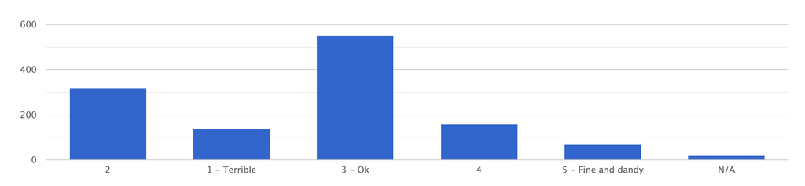

   Label the graph so that the reader understands the story you are telling.
3. *“Show data variation, not design variation.”*

   Pick colours that can help to tell the story. Don’t have more than 5 colours as it’s difficult to identify individual groups. Use the most commonly used types of graph.
4. *“In time-series displays of money, deflated and standardized units of monetary measurement are nearly always better than nominal units.”*

   Use appropriate units to ensure data are comparable. For diseases, consider presenting incidence as cases/100,000 people.
5. *“The number of information-carrying (variable) dimensions depicted should not exceed the number of dimensions in the data.”*

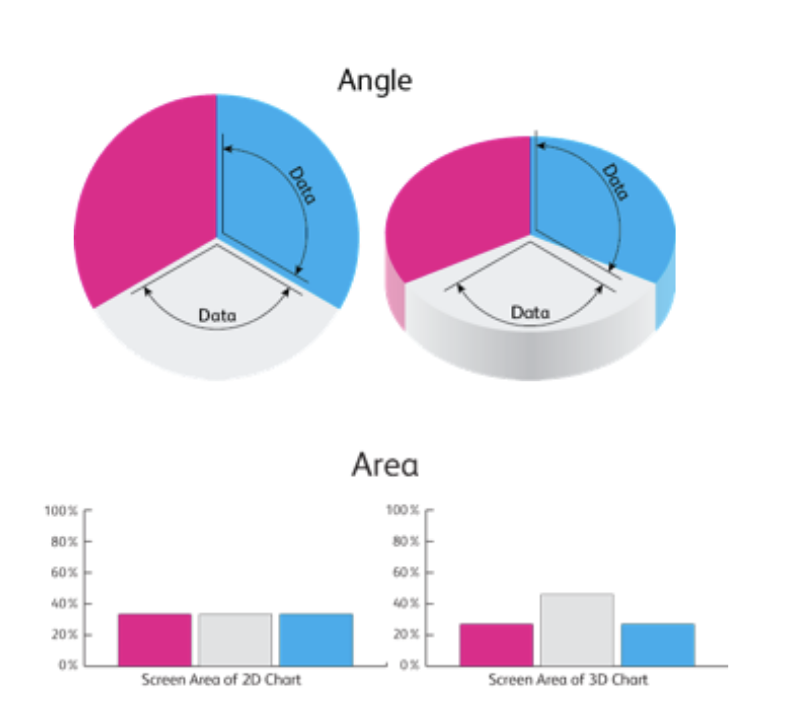

   Don’t use pie charts!
6. *“Graphics must not quote data out of context.”*

   Ensure your graph is telling the truth!

Due to the structure of code using ggplot these principles can be followed to ensure clean, clear graphics.

### Visualising the moving average

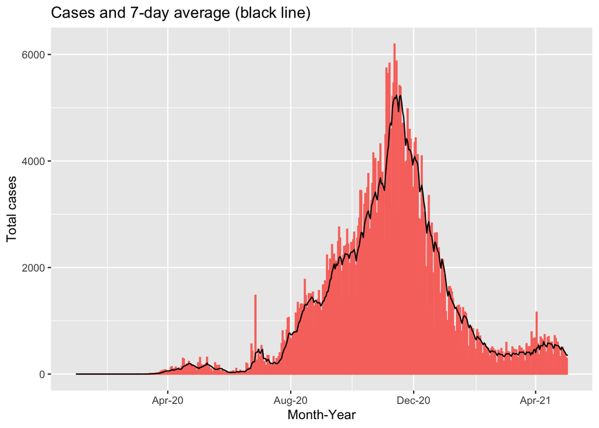

```r
moroocco_covid_cases_graph <- morocco_covid_cases_mean %>%
  ggplot() +
  geom_col(aes(x=date, y=cases, color=country)) +
  geom_line(aes(x=date, y=cases_7day_mean)) +
  labs(x='Month-Year',
       y='Total cases',
       title='Cases and 7-day average (black line)') +
  theme(legend.position='none') +
  scale_x_date(date_breaks = '4 months', #set x axis to have 2 month breaks
               date_minor_breaks = '2 months', #set x axis to have 1 month breaks
               date_labels = '%b-%y')  #change label for x axis

moroocco_covid_cases_graph
```

This chart shows the total number of COVID-19 cases for each day in Morocco between January 1, 2020 and May 3, 2021. The red bars show the reported case numbers for each day while the black line show the 7-day average of cases. We can see that there are several dates with substantially higher numbers of cases compared to the neighbouring dates. This could be due to increased testing on specific days but it is more likely due to delays in reporting leading to a backlog of cases reported on specific days. The black line “smooths” out these differences, allowing us to see the overall trend.

### Presenting your results in a table

The `gt` package provides a very flexible interface for building tables from your data.

```r
pacman::p_load(gt,here,dplyr)
```

The documentation describing the functions can be found [here](https://gt.rstudio.com/articles/case-study-gtcars.html). Below is an example using the dataset of COVID-19 cases in Northern Africa.

```r
northern_africa_cases_country_table <- northern_africa_cases_country %>%
  gt() %>%
   tab_header(
    title = md("COVID-19 in Northern Africa")
  ) %>%
  cols_label(
    country = "Country",
    total_covid_cases = "Count",
    percentage = "% of total cases in Northern Africa"
  ) %>%
    tab_spanner(
    label = "Confirmed cases",
    columns = c(total_covid_cases,percentage)
  ) %>%
    fmt_number(
    columns = total_covid_cases,
    decimals=0,
    use_seps = TRUE
  ) %>%
   cols_align(
    align = "center",
    columns = c(total_covid_cases, percentage)
  )
northern_africa_cases_country_table
```

COVID-19 in Northern Africa

| Country | Confirmed cases Count | Confirmed cases % of total cases in Northern Africa |
| --- | --- | --- |
| Morocco | 511,856 | 37.3% |
| Tunisia | 311,743 | 22.7% |
| Egypt | 228,584 | 16.7% |
| Libya | 178,335 | 13.0% |
| Algeria | 122,522 | 8.9% |
| Mauritania | 18,429 | 1.3% |

`gt` has many options for customising tables. To demonstrate this, we will build a table to show when each country in Africa recorded its first COVID-19 case. This example uses some of the techniques demonstrated in [this article](https://www.liamdbailey.com/post/making-beautiful-tables-with-gt/).

```r
first_cases_africa <- africa_covid_cases_long %>%
  select(date=date_format,region=AFRICAN_REGION, country=COUNTRY_NAME, cases) %>%
  group_by(region,country) %>%
  filter(cases>0) %>%
  filter(date == min(date, na.rm=TRUE)) %>%
  ungroup()

first_cases_africa_table <- first_cases_africa %>%
  select(region,country,date) %>%
  group_by(region) %>%
  arrange(date) %>%
gt() %>%
  tab_header(
    title = md("When did countries in Africa record their first case of COVID-19?")
  ) %>%
  fmt_date(
    columns = date,
    date_style = 4
  ) %>%
  opt_all_caps() %>%
  #Use the Chivo font
  #Note the great 'google_font' function in 'gt' that removes the need to pre-load fonts
  opt_table_font(
    font = list(
      google_font("Chivo"),
      default_fonts()
    )
  ) %>%
  cols_label(
    country = "Country",
    date = "Date"
  )  %>%
  cols_align(
    align = "center",
    columns = c(country, date)
  ) %>%
  tab_options(
    column_labels.border.top.width = px(3),
    column_labels.border.top.color = "transparent",
    table.border.top.color = "transparent",
    table.border.bottom.color = "transparent",
    data_row.padding = px(3),
    source_notes.font.size = 12,
    heading.align = "left",
    #Adjust grouped rows to make them stand out
    row_group.background.color = "grey") %>%
  tab_source_note(source_note = "Data: Compiled from national governments and WHO by Humanitarian Emergency Response Africa (HERA)")

first_cases_africa_table
```

When did countries in Africa record their first case of COVID-19?

| Country | Date |
| --- | --- |
| Northern Africa |  |
| Egypt | Friday 14 February 2020 |
| Algeria | Tuesday 25 February 2020 |
| Morocco | Monday 2 March 2020 |
| Tunisia | Monday 2 March 2020 |
| Mauritania | Friday 13 March 2020 |
| Libya | Tuesday 24 March 2020 |
| Western Africa |  |
| Nigeria | Thursday 27 February 2020 |
| Senegal | Friday 28 February 2020 |
| Togo | Friday 6 March 2020 |
| Burkina Faso | Monday 9 March 2020 |
| Cote d'Ivoire | Wednesday 11 March 2020 |
| Ghana | Thursday 12 March 2020 |
| Guinea | Thursday 12 March 2020 |
| Benin | Monday 16 March 2020 |
| Gambia | Monday 16 March 2020 |
| Liberia | Monday 16 March 2020 |
| Niger | Thursday 19 March 2020 |
| Guinea-Bissau | Wednesday 25 March 2020 |
| Mali | Wednesday 25 March 2020 |
| Sierra Leone | Tuesday 31 March 2020 |
| Southern Africa |  |
| South Africa | Thursday 5 March 2020 |
| Eswatini | Saturday 14 March 2020 |
| Namibia | Saturday 14 March 2020 |
| Zimbabwe | Friday 20 March 2020 |
| Angola | Saturday 21 March 2020 |
| Zambia | Sunday 22 March 2020 |
| Mozambique | Monday 23 March 2020 |
| Botswana | Monday 30 March 2020 |
| Malawi | Thursday 2 April 2020 |
| Lesotho | Tuesday 12 May 2020 |
| Central Africa |  |
| Cameroon | Friday 6 March 2020 |
| Democratic Republic of the Congo | Tuesday 10 March 2020 |
| Gabon | Thursday 12 March 2020 |
| Central African Republic | Saturday 14 March 2020 |
| Equatorial Guinea | Saturday 14 March 2020 |
| Chad | Thursday 19 March 2020 |
| Congo | Sunday 22 March 2020 |
| Burundi | Tuesday 31 March 2020 |
| Sao Tome and Principe | Monday 6 April 2020 |
| Eastern Africa |  |
| Ethiopia | Friday 13 March 2020 |
| Kenya | Friday 13 March 2020 |
| Sudan | Friday 13 March 2020 |
| Rwanda | Saturday 14 March 2020 |
| Somalia | Monday 16 March 2020 |
| Mayotte | Tuesday 17 March 2020 |
| Tanzania | Tuesday 17 March 2020 |
| Djibouti | Wednesday 18 March 2020 |
| Mauritius | Wednesday 18 March 2020 |
| Madagascar | Friday 20 March 2020 |
| Eritrea | Saturday 21 March 2020 |
| Uganda | Saturday 21 March 2020 |
| South Sudan | Monday 6 April 2020 |
| Comoros | Thursday 30 April 2020 |

Data: Compiled from national governments and WHO by Humanitarian Emergency Response Africa (HERA)